# Topic 4 - Classification using Naive Bayes and Linear Discriminant Analysis

MSDA7003 - Machine Learning

KT Wong

Faculty of Social Sciences, HKU

2024-10-04

The materials in this topic are drawn from Lantz (2023) and James et al. (2023)

## Motivation

- Weather estimates are based on probabilistic methods for describing uncertainty
- We use data on `past events` to extrapolate `future events`
  - the chance of rain
    - the proportion of prior days with similar atmospheric conditions on which precipitation occurred
  - A 80% chance of rain
    - in 80 out of 100 past cases with similar conditions, precipitation occurred somewhere in the area
- In this topic, we focus on machine learning methods using **probabilities** to do classification
  - We first discuss Naive Bayes method
  - then we introduce Linear Discriminant Analysis (and Quadratic Discriminant Analysis)

# Introduction to Naive Bayes

## General information

- the 18th-century mathematician Thomas Bayes developed foundational principles
  - describing the probability of events
  - how these probabilities should be revised in light of additional information
- Classifiers based on Bayesian methods utilize training data to calculate the probability of each outcome based on the evidence provided by feature values

## General information

- When the classifier is later applied to unlabeled data,
  - it uses these calculated probabilities to predict the most likely class for the new example
- Bayesian classifiers have been used for a variety of tasks, including:
  - Text classification, such as junk email (spam) filtering
  - Intrusion or anomaly detection in computer networks
  - Diagnosing medical conditions given a set of observed symptoms
  - Predicting the likelihood of a customer purchasing a product
  - Predicting whether the Fed is going to raise interest rates

## General information

- Bayesian classifiers are best applied to problems for which **the information from numerous attributes should be considered simultaneously** to estimate the overall probability of an outcome
- Many machine learning algorithms ignore features that have weak effects
- Bayesian methods utilize **all available evidence** to subtly change the predictions
  - even if a large portion of features have relatively *minor effects*, their *combined impact* in a Bayesian model could be quite large

## A re-cap of basic concepts/terminologies in probability

- Events and Trials
- Some examples

| Event | Trial |
| --- | --- |
| Head | A Coin Flipping |
| Rainy | A single day |
| Message is spam | An incoming email |
| Pass | An Exam |
| A job offer | A job interview |
| Win a mark six | A lottery ticket |

- A trial always results in some outcome happening
  - the probability of all possible outcomes of a trial must always sum to one
- A single event cannot happen and not happen simultaneously
  - an event is always mutually exclusive and exhaustive with its complement

## Joint probability

- There could be some non-mutually exclusive events in the same trial
- If certain events occur concurrently with the event of interest, we may be able to use them to make predictions
- Venn diagram

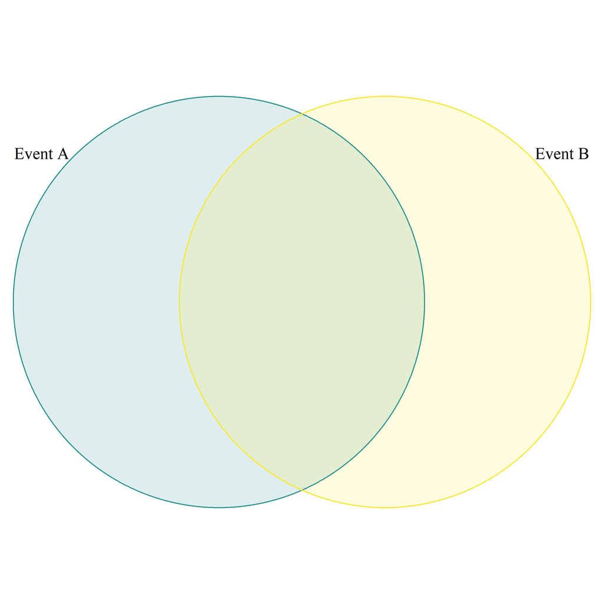

## Conditional Probability and Bayes’ theorem

- Independent events

$$P(A\cap B)=P(A)*P(B)$$

- Conditional probability
  - Given $P(B)>0$
    $$P(A|B)=\frac{P(A\cap B)}{P(B)}$$
- Bayes’ theorem
  $$P(A|B)=\frac{P(A\cap B)}{P(B)}=\frac{P(B|A)P(A)}{P(B)}$$

## Little Exercise

### An email and Viagra example

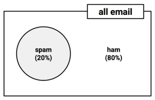

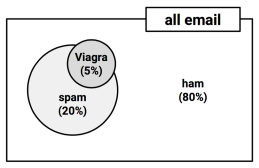

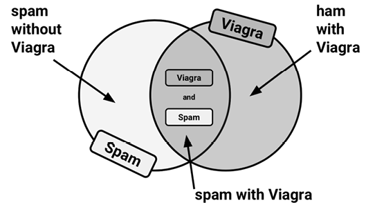

## Little Exercise

### An email and Viagra example

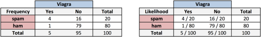

- $P(Viagra=Yes|Spam)$ =
- $P(Spam \cap Viagra)$ =
- $P(Spam|Viagra)$ =

## Naive Bayes Method

### Introduction

- a simple method for applying Bayes’ theorem to classification problem
- Naive Bayes assumes that all of the features in the dataset are equally important and independent
- in most cases, even when these assumptions are violated, Naive Bayes still performs surprisingly well
- Due to the algorithm’s versatility and accuracy across many types of conditions, particularly with smaller training datasets, Naive Bayes is often a reasonable baseline candidate for classification learning tasks

## Classification with Naive Bayes

### An email example

- The email contains four words: Viagra, money, groceries, and unsubscribe

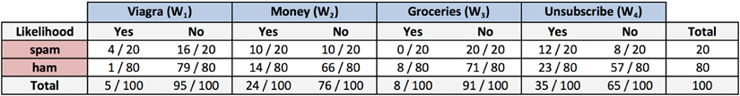

- The Naive Bayes learner is trained by constructing a likelihood table for the appearance of these four words (labeled $W_1$, $W_2$, $W_3$, and $W_4$) for 100 emails

## Classification with Naive Bayes

### An email example

- Using Bayes’ theorem, we can define the problem as shown in the following formula.
  - This computes the probability that a message is spam given that Viagra = Yes, Money = No, Groceries = No, and Unsubscribe = Yes

$$P(spam|W_1=Y, W_2=N, W_3=N, W_4=Y)=\frac{P(W_1=Y, W_2=N, W_3=N, W_4=Y|spam)P(spam)}{P(W_1=Y, W_2=N, W_3=N, W_4=Y)}$$

## Classification with Naive Bayes

- Naive Bayes makes the naive assumption of independence among events
  - assumes **class-conditional independence**
    - events are independent so long as they are conditioned on the same class value
- The conditional independence assumption allows us to use the probability rule for independent events
  - This simplifies the numerator by allowing us to multiply the individual conditional probabilities rather than computing a complex conditional joint probability

## Classification with Naive Bayes

### An email example

- In our case, it means that

$$P(W_1=Y, W_2=N, W_3=N, W_4=Y|spam)$$
$$=P(W_1=Y|spam)*P(W_2=N|spam)*P(W_3=N|spam)*P(W_4=Y|spam)$$

- The likelihood table is used to calculate the conditional probabilities of each word given the class value
  - $P(spam|W_1=Y, W_2=N, W_3=N, W_4=Y)=?$ (please do the calculation)
  - $P(spam|W_1=Y, W_2=N, W_3=N, W_4=N)=?$ (please do the calculation)

## Classification with Naive Bayes

- The Naive Bayes classification method used above can be summarized (or abstracted) by the following setup
- Let $K$ be the set of classes, i.e. $k=1, \dots, K$, and $p$ number of features, i.e. $X_1, \dots, X_p$
- The conditional probability of class $k$ given the features $x_1, \dots, x_p$ is given by

$$f_k(x) = P(X=x|Y=k) \quad \text{where} \; x=(x_1, \dots, x_p)$$

- The naive Bayes assume $f_k(x)=f_{k1}(x_1) \times f_{k2}(x_2) \times \cdots \times f_{kp}(x_p)$
- Under the navie Bayes assumption, the posterior probability of class $k$ given the features $x_1, \dots, x_p$ is given by

$$P(Y=k | X=x) = \frac{P(Y=k) \prod_{j=1}^p f_{kj}(x_j)}{\sum_{l=1}^K P(Y=l) \prod_{j=1}^p f_{lj}(x_j)}$$

## The Laplace estimator

- An example: an email containing “Viagra, groceries, money, and unsubscribe”
  - spam or not?
- The Laplace estimator adds a **small number** to **each of the counts** in the frequency table
  - ensures that each feature has a **non-zero probability** of occurring with each class
  - Typically, the Laplace estimator is set to one
    - ensures that each class-feature combination is found in the data at least once

## The Laplace estimator

- An illustration
  - Using a Laplace value of 1, we add 1 to each numerator in the likelihood function
  - Please show the new likelihood table (with the Laplace estimator)
- Exercise:
  - $P(spam|W_1=Y, W_2=N, W_3=Y, W_4=Y)$
  - $P(spam|W_1=N, W_2=Y, W_3=N, W_4=Y)$
  - compare the results with and without the Laplace estimator for the previous exercise

## Using numeric features with Naive Bayes

- Naive Bayes uses frequency tables for learning the data
  - each feature must be **categorical** in order to create the combinations of class and feature values comprising the matrix
- discretize numeric features
  - the numbers are put into categories known as bins

## Using numeric features with Naive Bayes

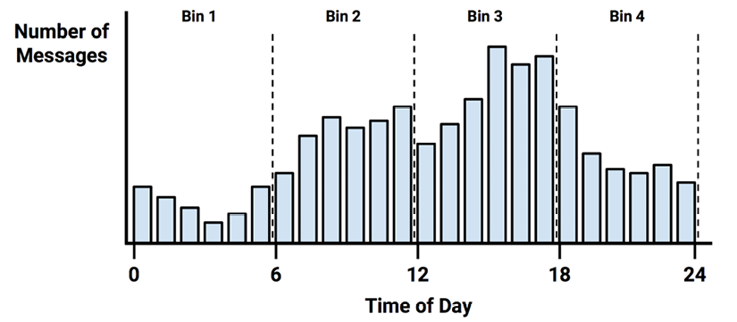

- Reminder: discretizing a numeric feature always results in a reduction of information
- The choice of the number of bins can have a significant impact on the performance of the model

## A Summary of the strengths and weaknesses of Naive Bayes

| Strengths | Weaknesses |
| --- | --- |
| Simple, fast, and very effective | Relies on assumption of equally important and independent features |
| Work well with noisy and missing data with large numbers of features | Not ideals for questions with many numeric features |
| less demanding on the size of training sample | Estimated probabilities are less reliable than the predicted classes |
| easy to obtain the predicted probability |  |

## Naive Bayes in R

- Several packages in R can be used to implement the Naive Bayes algorithm
  - `e1071` package
  - `klaR` package
  - `naivebayes` package _ `caret` package
  - `h2o` package
- Here, we apply the naive Bayes classifier with the **klaR** package

```r
nb_default<- klaR::NaiveBayes(as.factor(default) ~ balance + student, data = default)

pred_default_0.5 = ifelse(nb_prob_default > 0.5, "Yes", "No")
```

| Predicted | True default status No | True default status Yes | True default status Total |
| --- | --- | --- | --- |
| No | 9621 | 244 | 9865 |
| Yes | 46 | 89 | 135 |
| Total | 9667 | 333 | 10000 |

- (244+46)/10000 = 0.029 mis-classification rate

## Naive Bayes in R

```r
pred_default_0.2 = ifelse(nb_prob_default > 0.2, "Yes", "No")
```

| Predicted | True default status No | True default status Yes | True default status Total |
| --- | --- | --- | --- |
| No | 9339 | 130 | 9469 |
| Yes | 328 | 203 | 531 |
| Total | 9667 | 333 | 10000 |

- (130+328)/10000 = 0.046 mis-classification rate

# Let us now go to Linear Discriminant Analysis

## Introduction to Linear Discriminant Analysis

- Linear Discriminant Analysis (LDA) is a classification method that is based on Bayes’ theorem
- LDA is a **generative model** that estimates the probability of each class by modeling the distribution of the features for each class
- LDA is a linear classifier
  - assumes that the `features` are **normally distributed** and
  - that the variance of the features is the **same** for all classes
- LDA is a **parametric model**
  - it estimates the parameters of the normal distributions for each class

## Introduction to Linear Discriminant Analysis

- The probability of class $k$ given the features $X$ is given by

$$P(Y=k|X)=\frac{\pi_k f_k(X)}{\sum_{l=1}^K \pi_l f_l(X)}$$

$\quad$ where $f_k(x)=P(X=x|Y=k)$ is the density function of the features given class $k$ and $\pi_k=P(Y=k)$ is the prior probability of Y being class $k$

- For LDA, it uses normal densities for $f_k(x)$, separately for each class
- the decision rule is to assign the class with the highest probability
  - classify a new point according to the class with the highest posterior probability

## Linear Discriminant Analysis

### when $p=1$

- the Gaussian densities for each class are given by

$$f_k(x)=\frac{1}{\sqrt{2\pi}\sigma_k}e^{-\frac{1}{2\sigma_k^2}(x-\mu_k)^2}$$

- the common assumption is that the variance is the same for all classes, $\sigma_1^2=\sigma_2^2=\cdots=\sigma_K^2$
- recall that we define $p_k(x)=P(Y=k|X=x)$, which can be expressed

$$p_k(x)=\frac{\pi_k \frac{1}{\sqrt{2\pi}\sigma}e^{-\frac{1}{2\sigma^2}(x-\mu_k)^2}}{\sum\limits_{l=1}^K \pi_l \frac{1}{\sqrt{2\pi}\sigma}e^{-\frac{1}{2\sigma^2}(x-\mu_l)^2}}$$

## Linear Discriminant Analysis - Discriminant Functions ($p=1$)

- to see which of $p_k(x)$ is largest, this is equivalent to assigning $x$ to the class with the largest discriminant score

$$\delta_k(x)=x\frac{\mu_k}{\sigma^2}-\frac{\mu_k^2}{2\sigma^2}+\log(\pi_k)$$

- note that the discriminant score is a linear function of $x$
- Execrise:
  - if $K=2$ and $\pi_1=\pi_2=0.5$, $\mu_2=1$, the decision boundary is at $x=\frac{\mu_1 + \mu_2}{2}$

## Linear Discriminant Analysis

### $p=1$

- As usual, we don’t know these parameters
- we can use the training data to estimate the parameters
  - and then plug them into the rule to classify new observations
- The parameters are estimated by the following formulas

$$\begin{aligned}
\hat{\pi}_k &=\frac{n_k}{n} \\
\hat{\mu}_k &=\frac{1}{n_k}\sum_{i:y_i=k}x_i \\
\hat{\sigma}^2 &=\frac{1}{n-K}\sum_{k=1}^K\sum_{i:y_i=k}(x_i-\hat{\mu}_k)^2 \\
&= \frac{1}{n-K}\sum_{k=1}^K (n_k-1) \hat{\sigma}_k^2
\end{aligned}$$

$\quad$ where $\hat{\sigma}^2_k= \frac{1}{n_k -1}\sum_{i: y_i=k}(x_i - \hat{\mu}_k)^2$

## Linear Discriminant Analysis

### when $p>1$

- when $p>1$, the Gaussian densities for each class are given by

$$f_k(x)=\frac{1}{(2\pi)^{p/2}|\Sigma_k|^{1/2}}e^{-\frac{1}{2}(x-\mu_k)^T\Sigma_k^{-1}(x-\mu_k)}$$

$\quad$ where $\Sigma_k$ is the covariance matrix for class $k$ and $|\Sigma_k|$ is the determinant of $\Sigma_k$

- in LDA, we assume that $\Sigma_1=\Sigma_2=\cdots=\Sigma_K=\Sigma$
- the corresponding discriminant function is given by

$$\delta_k(x)=x^T\Sigma^{-1}\mu_k-\frac{1}{2}\mu_k^T\Sigma^{-1}\mu_k+\log(\pi_k)$$

- note that the discriminant function is a still linear function of $x$

## Linear Discriminant Analysis

### illustration when $p=2$ and $K=3$

- assume $\pi_1=\pi_2=\pi_3=\frac{1}{3}$

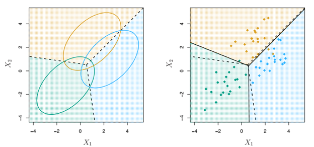

## Linear Discriminant Analysis

### from the discriminant function to the posterior probability

- after obtaining the estimates $\hat{\delta}_k(x)$, we cam obtain the posterior probability

$$\hat{p}_k(x)=\frac{e^{\hat{\delta}_k(x)}}{\sum_{l=1}^K e^{\hat{\delta}_l(x)}}$$

- hence, classifying to the largest $\hat{\delta}_k(x)$ is equivalent to classifying to the largest $\hat{p}_k(x)$
- Note that when $K=2$, we classify to `class 1` if $\hat{p}_1(x)>0.5$ and to `class 2` otherwise

## Linear Discriminant Analysis

### Default Data example

- The data contains information on credit applicants
- The goal is to predict whether an applicant will default on a loan

```r
library(tidyverse)
library(MASS)

credit<- read.csv("https://raw.githubusercontent.com/kwan-MSDA/MSDA7003/main/Default.csv")

credit$default <- as.factor(credit$default)

lda_model <- lda(default ~ ., data = credit)
```

|  | Actual No | Actual Yes |
| --- | --- | --- |
| No | 9645 | 254 |
| Yes | 22 | 79 |

- $(22 + 254)/10000$
  - $2.76\%$ mis-classification rate!

## Quadratic Discriminant Analysis (QDA)

- When the covariance matrices $\Sigma_k$ are different in each class, the quadratic terms in the discriminant functions will not cancel out

$$\delta_k(x) = -\frac{1}{2} (x-\mu_k)^T \Sigma_k^{-1} (x-\mu_k) - \frac{1}{2} \log |\Sigma_k| + \log \pi_k$$

```r
library(tidyverse)
library(MASS)

credit<- read.csv("https://raw.githubusercontent.com/kwan-MSDA/MSDA7003/main/Default.csv")

credit$default <- as.factor(credit$default)

qda_model <- qda(default ~ ., data = credit)
```

|  | Actual No | Actual Yes |
| --- | --- | --- |
| No | 9636 | 239 |
| Yes | 31 | 94 |

- $(31 + 239)/10000$
  - $2.7\%$ mis-classification rate!

## Let us compare with naive Bayes

- Recall that naive Bayes assumes that the features are conditionally independent given the class
- Useful when $p$ is large
  - multivariate methods like QDA (and even LDA) break down
  - the curse of dimensionality
    - the problem of estimating densities in high dimensions
    - the number of parameters grows exponentially with the number of dimensions
- Gaussian naive Bayes assumes each $\Sigma_k$ is diagonal

$$\begin{aligned}
\delta_k(x) &\propto \log \left [\pi_k\prod_{j=1}^p f_{kj}(x_j) \right ] \\
&=- \frac{1}{2}\sum_{j=1}^p \left [ \frac{(x_j-\mu_{kj})^2}{\sigma^2_{kj}} +\log \sigma^2_{kj} \right ] + \log \pi_k
\end{aligned}$$

## Logistic Regression vs LDA

- For a two-class problem, it can be shown that LDA and logistic regression are equivalent
- for LDA,

$$\log \frac{P(Y=1|X=x)}{P(Y=0|X=x)} = \beta_0 + \beta^T x=\beta_0 + \sum_{j=1}^p \beta_j x_j$$

- it has the same form as logistic regression
- the difference is in the estimation of the coefficients
- logistic regression uses the conditional likelihood based on $P(Y|X)$
  - it is known as discriminative learning model
  - it is a direct probability model
- LDA uses the joint(full) likelihood based on $P(X,Y)$
  - it is known as generative learning model
- in practice, the results are often similar, unless in some special cases

## Reference

James, G., D. Witten, T. Hastie, and R. Tibshirani. 2023. *An Introduction to Statistical Learning with Applications in r*. Second edition. Springer.

Lantz, Brett. 2023. *Machine Learning with r : Learn Techniques for Building and Improving Machine Learning Models, from Data Preparation to Model Tuning, Evaluation, and Working with Big Data*. Fourth edition. Expert Insight. Birmingham, UK: Packt Publishing Limited.